# Exploring the quotes between the great philosophers

As we all know, academical research is like standing upon the shoulders of giants, and keep experimenting and exploring. Scholars, including philosophers, they learn from each other, question each other and resolve unanswered problems.  
Sometimes the influence is subtle, sometimes it's direct and far-reaching, which can be reflected in the quotes and references.

In this project, I tried to explore the quotes between the great philosophers and see what we can find out. Maybe philosophers from the same school like to quotes each other, maybe there are a few very influential philosophers that have been mentioned a lot in later generations, or maybe the more a philosopher is mentioned in an article, the more they share perspectives and ideas.

## overview

```python
df
```

|  | title | author | school | sentence_spacy | sentence_str | original_publication_date | corpus_edition_date | sentence_length | sentence_lowered | tokenized_txt | lemmatized_str |
| --- | --- | --- | --- | --- | --- | --- | --- | --- | --- | --- | --- |
| 0 | Plato - Complete Works | Plato | plato | What's new, Socrates, to make you leave your ... | What's new, Socrates, to make you leave your ... | -350 | 1997 | 125 | what's new, socrates, to make you leave your ... | ['what', 'new', 'socrates', 'to', 'make', 'you... | what be new , Socrates , to make -PRON- lea... |
| 1 | Plato - Complete Works | Plato | plato | Surely you are not prosecuting anyone before t... | Surely you are not prosecuting anyone before t... | -350 | 1997 | 69 | surely you are not prosecuting anyone before t... | ['surely', 'you', 'are', 'not', 'prosecuting',... | surely -PRON- be not prosecute anyone before ... |
| 2 | Plato - Complete Works | Plato | plato | The Athenians do not call this a prosecution b... | The Athenians do not call this a prosecution b... | -350 | 1997 | 74 | the athenians do not call this a prosecution b... | ['the', 'athenians', 'do', 'not', 'call', 'thi... | the Athenians do not call this a prosecution ... |
| 3 | Plato - Complete Works | Plato | plato | What is this you say? | What is this you say? | -350 | 1997 | 21 | what is this you say? | ['what', 'is', 'this', 'you', 'say'] | what be this -PRON- say ? |
| 4 | Plato - Complete Works | Plato | plato | Someone must have indicted you, for you are no... | Someone must have indicted you, for you are no... | -350 | 1997 | 101 | someone must have indicted you, for you are no... | ['someone', 'must', 'have', 'indicted', 'you',... | someone must have indict -PRON- , for -PRON- ... |
| ... | ... | ... | ... | ... | ... | ... | ... | ... | ... | ... | ... |
| 360803 | Women, Race, And Class | Davis | feminism | But the socialization of housework including m... | But the socialization of housework including m... | 1981 | 1981 | 142 | but the socialization of housework including m... | ['but', 'the', 'socialization', 'of', 'housewo... | but the socialization of housework include me... |
| 360804 | Women, Race, And Class | Davis | feminism | The only significant steps toward endingdomest... | The only significant steps toward endingdomest... | 1981 | 1981 | 117 | the only significant steps toward endingdomest... | ['the', 'only', 'significant', 'steps', 'towar... | the only significant step toward endingdomest... |
| 360805 | Women, Race, And Class | Davis | feminism | Working women, therefore, have a special and v... | Working women, therefore, have a special and v... | 1981 | 1981 | 90 | working women, therefore, have a special and v... | ['working', 'women', 'therefore', 'have', 'spe... | working woman , therefore , have a special an... |
| 360806 | Women, Race, And Class | Davis | feminism | Moreover, under capitalism, campaigns for jobs... | Moreover, under capitalism, campaigns for jobs... | 1981 | 1981 | 199 | moreover, under capitalism, campaigns for jobs... | ['moreover', 'under', 'capitalism', 'campaigns... | moreover , under capitalism , campaign for jo... |
| 360807 | Women, Race, And Class | Davis | feminism | This strategy calls into question the validity... | This strategy calls into question the validity... | 1981 | 1981 | 126 | this strategy calls into question the validity... | ['this', 'strategy', 'calls', 'into', 'questio... | this strategy call into question the validity... |

360808 rows × 11 columns

```python
import ipywidgets as widgets
from IPython.display import display, HTML

javascript_functions = {False: "hide()", True: "show()"}
button_descriptions  = {False: "Show code", True: "Hide code"}


def toggle_code(state):

    """
    Toggles the JavaScript show()/hide() function on the div.input element.
    """

    output_string = "<script>$(\"div.input\").{}</script>"
    output_args   = (javascript_functions[state],)
    output        = output_string.format(*output_args)

    display(HTML(output))


def button_action(value):

    """
    Calls the toggle_code function and updates the button description.
    """

    state = value.new

    toggle_code(state)

    value.owner.description = button_descriptions[state]


state = False
toggle_code(state)

button = widgets.ToggleButton(state, description = button_descriptions[state])
button.observe(button_action, "value")

display(button)
```

```python
print(['Plato', 'Aristotle', 'Locke', 'Hume', 'Berkeley', 'Spinoza',
       'Leibniz', 'Descartes', 'Malebranche', 'Russell', 'Moore',
       'Wittgenstein', 'Lewis', 'Quine', 'Popper', 'Kripke', 'Foucault',
       'Derrida', 'Deleuze', 'Merleau-Ponty', 'Husserl', 'Heidegger',
       'Kant', 'Fichte', 'Hegel', 'Marx', 'Lenin', 'Smith', 'Ricardo',
       'Keynes', 'Epictetus', 'Marcus Aurelius', 'Nietzsche',
       'Wollstonecraft', 'Beauvoir', 'Davis'])
```

```
['Plato', 'Aristotle', 'Locke', 'Hume', 'Berkeley', 'Spinoza', 'Leibniz', 'Descartes', 'Malebranche', 'Russell', 'Moore', 'Wittgenstein', 'Lewis', 'Quine', 'Popper', 'Kripke', 'Foucault', 'Derrida', 'Deleuze', 'Merleau-Ponty', 'Husserl', 'Heidegger', 'Kant', 'Fichte', 'Hegel', 'Marx', 'Lenin', 'Smit…
```

There are 36 philosophers in the dataset.

Quesitions:

- Is there any references in their articles?
- If a philosopher quotes the another philosopher a lot, will their ideas and articles similar?
- Why do some philosphers quote certain philosophers very often?

## Reference

Is there any philosopher or philosophical article title mentioned?

### Are there titles quoted in the articles?

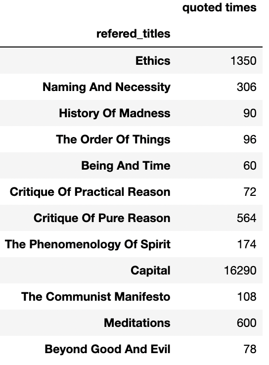

```python
from IPython.display import Image
Image("../figs/titlesquoted.jpeg", width=300)
```

Other than the frequently used words like 'capital', 'ethics' and 'Meditations', there's nearly no direct citation in the text.

### Are there philosophers quoted in the articles?

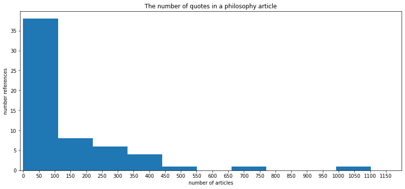

```python
fig,ax = plt.subplots(1,1,figsize=(14,6));

plt.hist(references.sum(axis=0)[1:])

ax.set_xlim([-10, 1200])
plt.xticks(np.arange(0, 1200, 50))

ax.set_title('The number of quotes in a philosophy article')
ax.set_ylabel('number references')
ax.set_xlabel('number of articles');
```

#### Who is influential among philosophers?

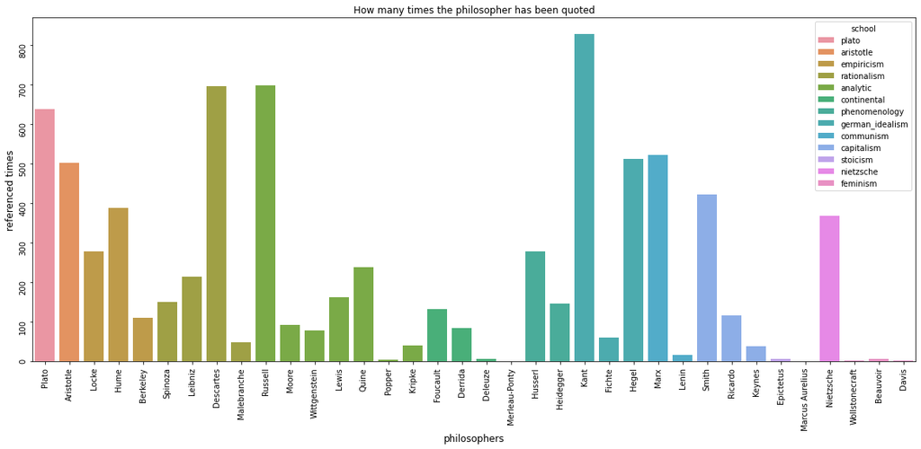

```python
fig,ax = plt.subplots(1,1,figsize=(20,8));

sns.barplot(x='author', y='references', data=df2, hue='school', dodge=False);
ax.set_xlabel('philosophers', fontsize=12);
ax.set_ylabel('referenced times', fontsize=12);
ax.tick_params(rotation=90)
ax.set_title('How many times the philosopher has been quoted');
```

The philosophers often being referenced are: Kant, Russell, Descartes, Plato.

We can also find the most authoritative philosopher (if being quoted a lot means authority) of each school. For example, in analytic, Russell is no wonder the most authoritative one. In german idealism, Kant stands out, but at the same time, Hegel is very influential as well.

#### Do they have a preference?

```python
df3 = df3[(df3.author != df3['most mentioned']) & (df3['mention time'] != 0)]
df3.sort_values(by='mention time', ascending=False)[:20].set_index('title')
```

| title | author | school | most mentioned | mention time | mentioned school |
| --- | --- | --- | --- | --- | --- |
| Philosophical Troubles | Kripke | analytic | Russell | 485 | analytic |
| Essential Works Of Lenin | Lenin | communism | Marx | 382 | communism |
| Writing And Difference | Derrida | continental | Hegel | 177 | german_idealism |
| Science Of Logic | Hegel | german_idealism | Kant | 172 | german_idealism |
| The Search After Truth | Malebranche | rationalism | Aristotle | 139 | aristotle |
| On The Principles Of Political Economy And Taxation | Ricardo | capitalism | Smith | 127 | capitalism |
| Lewis - Papers | Lewis | analytic | Hume | 122 | empiricism |
| Difference And Repetition | Deleuze | continental | Plato | 122 | plato |
| Off The Beaten Track | Heidegger | phenomenology | Nietzsche | 120 | nietzsche |
| History Of Madness | Foucault | continental | Descartes | 112 | rationalism |
| The Crisis Of The European Sciences And Phenomenology | Husserl | phenomenology | Kant | 98 | german_idealism |
| Capital | Marx | communism | Smith | 91 | capitalism |
| The Phenomenology Of Perception | Merleau-Ponty | phenomenology | Husserl | 84 | phenomenology |
| Naming And Necessity | Kripke | analytic | Aristotle | 80 | aristotle |
| Anti-Oedipus | Deleuze | continental | Marx | 77 | communism |
| Aristotle - Complete Works | Aristotle | aristotle | Plato | 76 | plato |
| Being And Time | Heidegger | phenomenology | Kant | 69 | german_idealism |
| On Certainty | Wittgenstein | analytic | Moore | 58 | analytic |
| Quintessence | Quine | analytic | Russell | 55 | analytic |
| The System Of Ethics | Fichte | german_idealism | Kant | 50 | german_idealism |

I extracted the most frequently mentioned philosopher for each article and it shows some philosopher has a certain preference. For instance, in Kripke's 'Philosophical Troubles', he mentioned Russell 485 times, who's from the same school with himself, analytics.  
But there's also cases that the philosopher's preferred author is from another school. Like Derrida mentioned Hegel 177 times in his 'Writing And Difference', but they're from different school. Derrida is from continental but Hegel is a german idealism, which also indicates that all the philosophy schools are not independent but interconnected.

### Example1: Philosophical Troubles - Kripke & Russell

Kripke mentioned Russell 485 times in his 'Philosophical Troubles'.

### 1. sentiment analysis

"It was I think settled quite well by Bertrand Russell in his notion of the scope of a description."  
"Russell brings this out by saying that in such a statement, the first occurrence of the description 'the author of Hamlet' has large scope."

We can tell that Kripke shares a lot perspectives of Ressell.

#### If there's any attitude towards Ressell. Admire? Respectful?

**For the whole article:**

```python
df_output = pd.merge(df_t, t_df_cleaned, on='row_id', how='inner')
df_output
```

|  | row_id | sentence_lowered | sentiment_type | sentiment_score |
| --- | --- | --- | --- | --- |
| 0 | 1 | a problem which has arisen frequently in conte... | compound | -0.4019 |
| 1 | 2 | this question is phrased by analogy with the w... | compound | 0.0000 |
| 2 | 3 | in both cases, it has usually been taken for g... | compound | 0.2500 |
| 3 | 4 | i do not intend to deal with the kantian quest... | compound | -0.4939 |
| 4 | 5 | i will not discuss who was right on the possib... | compound | 0.0000 |
| ... | ... | ... | ... | ... |
| 9793 | 9794 | i discussed the case of too in part just now. | compound | 0.0000 |
| 9794 | 9795 | the rules need not be the same for all the pre... | compound | 0.0000 |
| 9795 | 9796 | normally the presuppositions are the ones pred... | compound | 0.0000 |
| 9796 | 9797 | there may well be cases that appear to be coun... | compound | -0.4678 |
| 9797 | 9798 | such cases often seem to involve some special ... | compound | 0.4019 |

9798 rows × 4 columns

Polarity score:  
scores in the range of -1 to -0.5 typically indicates negative sentiment;  
greater than -0.5 and less than +0.5 typically indicates neutral sentiment;  
in the range of +0.5 to 1 typically indicates positive sentiment.

```python
df_output.sentiment_score.describe()
```

```
count    9798.000000
mean        0.035593
std         0.337712
min        -0.933100
25%         0.000000
50%         0.000000
75%         0.258400
max         0.966100
Name: sentiment_score, dtype: float64
```

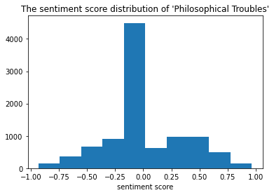

```python
fig,ax = plt.subplots(1,1);

plt.hist(df_output.sentiment_score);

ax.set_title("The sentiment score distribution of 'Philosophical Troubles'")
ax.set_xlabel('sentiment score');
```

Generally, it's neutral.  
The min value is -0.933100, which indicates the polarity or intensity of the most negative response is strongly negative (range of sentiment polarity score is -1 to +1).  
The max value is +0.966100, which indicates the polarity or intensity of the most positive response is highly positive.  
The mean value is +0.035593 which indicates the average polarity or intensity of sentiment across all responses is almost neutral.

**For sentences mentioning 'Russell':**

```python
df_russell.sentiment_score.describe()
```

```
count    441.000000
mean       0.063173
std        0.364153
min       -0.851900
25%       -0.019100
50%        0.000000
75%        0.338400
max        0.940300
Name: sentiment_score, dtype: float64
```

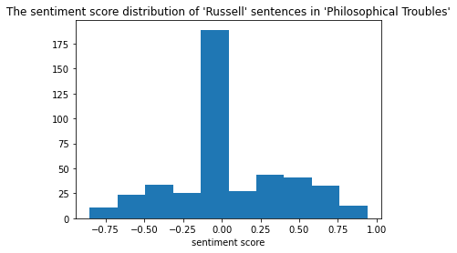

```python
fig,ax = plt.subplots(1,1);

plt.hist(df_russell.sentiment_score);

ax.set_title("The sentiment score distribution of 'Russell' sentences in 'Philosophical Troubles'")
ax.set_xlabel('sentiment score');
```

Similarly, the sentiment of sentences mentioned Russell is averagely and mostly neutral, and other negative or positive attitudes are evenly distributed.

example of highly negative:

```python
df_russell[df_russell.sentiment_score < -0.8].sentence_lowered.iloc[0]
```

```
"the premise of the argument we are considering for the classic position of frege and russell that whenever two codesignative names fail to be interchangeable in the expression of a speaker's beliefs, failure of interchangeability arises from a difference in the 'defining' descriptions the speaker a…
```

example of highly positive:

```python
df_russell[df_russell.sentiment_score > 0.9].sentence_lowered.iloc[1]
```

```
"for example taking for the moment 'cicero' and 'tully' as 'logically proper names,' russell would hold that if i judge that cicero admired tully, i am related to cicero, tully, and the admiration relation in a certain way: since cicero is tully, i am related in exactly the same way to tully, cicero…
```

The result makes sense as most citations are just proof of arguements, not a personal attitude towards Russell.

### 2. similarity btw Kripke and Russell's articles

### Similarity Matrix of the dataset

Transform the documents into TF-IDF vectors, remove the punctuations, and then compute the cosine similarity between them.

reasons: cosine similarity is generally preferred over Euclidean distance when working with text data as cosine similarity is not affected by the magnitude/length of the feature vectors.

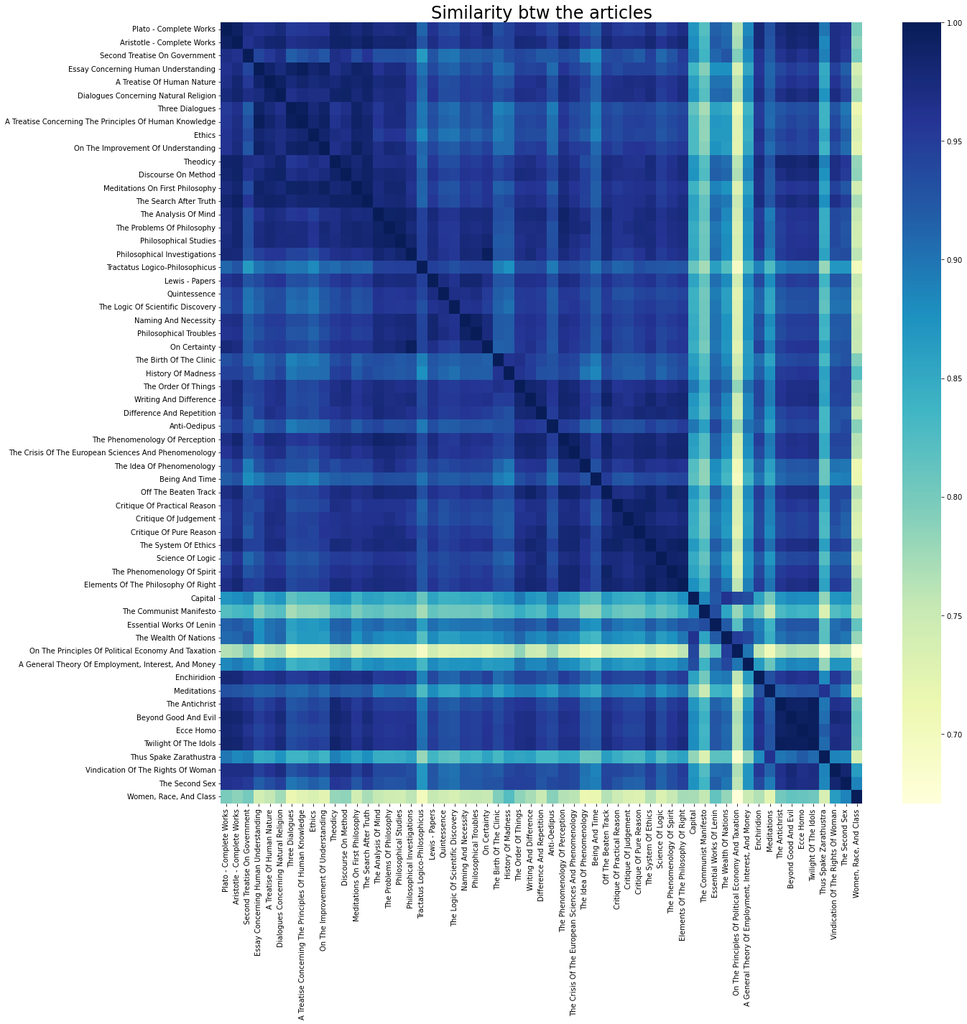

```python
np.fill_diagonal(arr2, 1)
create_heatmap(cosine_similarity(arr2))
```

Notice there're bright lines on 'Women, Race And Class', 'On the principle of Political Economy And Taxation', which means they are not similar with all the other articles.

```python
texts = texts[['title', 'author', 'school', 'text', 'similar article',
               'similar article author', 'similar article school', 'similarity']]
texts
```

|  | title | author | school | text | similar article | similar article author | similar article school | similarity |
| --- | --- | --- | --- | --- | --- | --- | --- | --- |
| 0 | Plato - Complete Works | Plato | plato | what's new, socrates, to make you leave your ... | Aristotle - Complete Works | Aristotle | aristotle | 0.742036 |
| 1 | Aristotle - Complete Works | Aristotle | aristotle | when things have only a name in common and th... | Plato - Complete Works | Plato | plato | 0.742036 |
| 2 | Second Treatise On Government | Locke | empiricism | reader, thou hast here the beginning and end o... | Plato - Complete Works | Plato | plato | 0.553567 |
| 3 | Essay Concerning Human Understanding | Locke | empiricism | i have put into thy hands what has been the di... | A Treatise Concerning The Principles Of Human ... | Berkeley | empiricism | 0.843079 |
| 4 | A Treatise Of Human Nature | Hume | empiricism | my design in the present work is sufficiently ... | Dialogues Concerning Natural Religion | Hume | empiricism | 0.731468 |
| 5 | Dialogues Concerning Natural Religion | Hume | empiricism | it has been remarked, my that though the ancie... | A Treatise Of Human Nature | Hume | empiricism | 0.731468 |
| 6 | Three Dialogues | Berkeley | empiricism | good morrow, hylas: i did not expect to find ... | A Treatise Concerning The Principles Of Human ... | Berkeley | empiricism | 0.839936 |
| 7 | A Treatise Concerning The Principles Of Human ... | Berkeley | empiricism | philosophy being nothing else but it may with ... | Essay Concerning Human Understanding | Locke | empiricism | 0.843079 |
| 8 | Ethics | Spinoza | rationalism | by that which is self caused, i mean that of w... | On The Improvement Of Understanding | Spinoza | rationalism | 0.683804 |
| 9 | On The Improvement Of Understanding | Spinoza | rationalism | after experience had taught me that all the u... | Meditations On First Philosophy | Descartes | rationalism | 0.751992 |
| 10 | Theodicy | Leibniz | rationalism | it has ever been seen that men in general have... | The Search After Truth | Malebranche | rationalism | 0.728630 |
| 11 | Discourse On Method | Descartes | rationalism | if this discourse appear too long to be read a... | The Search After Truth | Malebranche | rationalism | 0.676667 |
| 12 | Meditations On First Philosophy | Descartes | rationalism | to these wisest and most distinguished men, th... | On The Improvement Of Understanding | Spinoza | rationalism | 0.751992 |
| 13 | The Search After Truth | Malebranche | rationalism | the mind of man is by its na ure situated, as ... | Meditations On First Philosophy | Descartes | rationalism | 0.738433 |
| 14 | The Analysis Of Mind | Russell | analytic | this book has grown out of an attempt to harmo... | Philosophical Studies | Moore | analytic | 0.674759 |
| 15 | The Problems Of Philosophy | Russell | analytic | i have confined myself in the main to those p... | Philosophical Studies | Moore | analytic | 0.701063 |
| 16 | Philosophical Studies | Moore | analytic | all the papers contained in this volume, excep... | The Problems Of Philosophy | Russell | analytic | 0.701063 |
| 17 | Philosophical Investigations | Wittgenstein | analytic | these words, it seems to me, give us a particu... | On Certainty | Wittgenstein | analytic | 0.790176 |
| 18 | Tractatus Logico-Philosophicus | Wittgenstein | analytic | and whatever a man knows, whatever is not mere... | Philosophical Studies | Moore | analytic | 0.469461 |
| 19 | Lewis - Papers | Lewis | analytic | here, misprints apart, they are reprinted in t... | Philosophical Troubles | Kripke | analytic | 0.593805 |
| 20 | Quintessence | Quine | analytic | less a science a advanced , more its terminol... | Lewis - Papers | Lewis | analytic | 0.521870 |
| 21 | The Logic Of Scientific Discovery | Popper | analytic | in my old of i tried to explain too brieﬂy, i ... | Quintessence | Quine | analytic | 0.492076 |
| 22 | Naming And Necessity | Kripke | analytic | originally i had intended to revise or augment... | Philosophical Troubles | Kripke | analytic | 0.697689 |
| 23 | Philosophical Troubles | Kripke | analytic | a problem which has arisen frequently in conte... | Naming And Necessity | Kripke | analytic | 0.697689 |
| 24 | On Certainty | Wittgenstein | analytic | if you do know that here is one hand,' we'll g... | Philosophical Investigations | Wittgenstein | analytic | 0.790176 |
| 25 | The Birth Of The Clinic | Foucault | continental | for us, the human body defines, by natural ri... | The Order Of Things | Foucault | continental | 0.517281 |
| 26 | History Of Madness | Foucault | continental | at the end of the middle ages, leprosy disappe... | The Order Of Things | Foucault | continental | 0.491530 |
| 27 | The Order Of Things | Foucault | continental | this book first arose out of a passage in bor... | The Phenomenology Of Perception | Merleau-Ponty | phenomenology | 0.612600 |
| 28 | Writing And Difference | Derrida | continental | if it recedes one day, leaving behind its wor... | Off The Beaten Track | Heidegger | phenomenology | 0.624851 |
| 29 | Difference And Repetition | Deleuze | continental | repetition and difference repetition is not g... | Science Of Logic | Hegel | german_idealism | 0.575988 |
| 30 | Anti-Oedipus | Deleuze | continental | during the years (i am referring to europe), ... | Writing And Difference | Derrida | continental | 0.447712 |
| 31 | The Phenomenology Of Perception | Merleau-Ponty | phenomenology | what is phenomenology? it may seem strange th... | The Crisis Of The European Sciences And Phenom... | Husserl | phenomenology | 0.682466 |
| 32 | The Crisis Of The European Sciences And Phenom... | Husserl | phenomenology | is there, in view of their constant successes... | The Phenomenology Of Perception | Merleau-Ponty | phenomenology | 0.682466 |
| 33 | The Idea Of Phenomenology | Husserl | phenomenology | in earlier lectures i drew a distinction betwe... | The Problems Of Philosophy | Russell | analytic | 0.581029 |
| 34 | Being And Time | Heidegger | phenomenology | the text of first appeared in the spring of in... | The Crisis Of The European Sciences And Phenom... | Husserl | phenomenology | 0.439300 |
| 35 | Off The Beaten Track | Heidegger | phenomenology | ofarta originb means here that from where and ... | The Phenomenology Of Spirit | Hegel | german_idealism | 0.678476 |
| 36 | Critique Of Practical Reason | Kant | german_idealism | why this critique is titled a critique not of ... | The System Of Ethics | Fichte | german_idealism | 0.699788 |
| 37 | Critique Of Judgement | Kant | german_idealism | the faculty of knowledge from a priori princip... | Critique Of Pure Reason | Kant | german_idealism | 0.663009 |
| 38 | Critique Of Pure Reason | Kant | german_idealism | of our own person we will say nothing. but as ... | Critique Of Practical Reason | Kant | german_idealism | 0.687914 |
| 39 | The System Of Ethics | Fichte | german_idealism | i will begin by characterizing the task of phi... | Elements Of The Philosophy Of Right | Hegel | german_idealism | 0.749141 |
| 40 | Science Of Logic | Hegel | german_idealism | what was hitherto called 'metaphysics' has bee... | Elements Of The Philosophy Of Right | Hegel | german_idealism | 0.676729 |
| 41 | The Phenomenology Of Spirit | Hegel | german_idealism | it is custo ary to preface a work with an expl... | Elements Of The Philosophy Of Right | Hegel | german_idealism | 0.737720 |
| 42 | Elements Of The Philosophy Of Right | Hegel | german_idealism | this textbook is a more extensive, and in part... | The System Of Ethics | Fichte | german_idealism | 0.749141 |
| 43 | Capital | Marx | communism | the wealth of those societies in which the ca... | On The Principles Of Political Economy And Tax... | Ricardo | capitalism | 0.626149 |
| 44 | The Communist Manifesto | Marx | communism | a spectre is haunting europe the spectre of c... | Essential Works Of Lenin | Lenin | communism | 0.523023 |
| 45 | Essential Works Of Lenin | Lenin | communism | which are directly related to the question of ... | The Communist Manifesto | Marx | communism | 0.523023 |
| 46 | The Wealth Of Nations | Smith | capitalism | the annual labour of every nation is the fund... | On The Principles Of Political Economy And Tax... | Ricardo | capitalism | 0.739807 |
| 47 | On The Principles Of Political Economy And Tax... | Ricardo | capitalism | it has been observed by adam smith, that the ... | The Wealth Of Nations | Smith | capitalism | 0.739807 |
| 48 | A General Theory Of Employment, Interest, And ... | Keynes | capitalism | capitalism is not for the faint of heart. it ... | On The Principles Of Political Economy And Tax... | Ricardo | capitalism | 0.473301 |
| 49 | Enchiridion | Epictetus | stoicism | there are things which are within our power, a... | Plato - Complete Works | Plato | plato | 0.595235 |
| 50 | Meditations | Marcus Aurelius | stoicism | whensoever thou wilt rejoice thyself, think a... | Thus Spake Zarathustra | Nietzsche | nietzsche | 0.645061 |
| 51 | The Antichrist | Nietzsche | nietzsche | this book belongs to the most rare of men. pe... | Twilight Of The Idols | Nietzsche | nietzsche | 0.888329 |
| 52 | Beyond Good And Evil | Nietzsche | nietzsche | that truth is a woman is there not ground for... | Twilight Of The Idols | Nietzsche | nietzsche | 0.796427 |
| 53 | Ecce Homo | Nietzsche | nietzsche | as it is my intention within a very short tim... | Twilight Of The Idols | Nietzsche | nietzsche | 0.816398 |
| 54 | Twilight Of The Idols | Nietzsche | nietzsche | to maintain a cheerful attitude of mind in the... | The Antichrist | Nietzsche | nietzsche | 0.888329 |
| 55 | Thus Spake Zarathustra | Nietzsche | nietzsche | when zarathustra was thirty years old, he left... | Meditations | Marcus Aurelius | stoicism | 0.645061 |
| 56 | Vindication Of The Rights Of Woman | Wollstonecraft | feminism | having read with great pleasure a pamphlet, w... | The Second Sex | Beauvoir | feminism | 0.679300 |
| 57 | The Second Sex | Beauvoir | feminism | i hesitated a long time before writing a book ... | Vindication Of The Rights Of Woman | Wollstonecraft | feminism | 0.679300 |
| 58 | Women, Race, And Class | Davis | feminism | when the influential scholar ulrich. phillips ... | The Second Sex | Beauvoir | feminism | 0.497830 |

There are 2 articles of Russell in the dataset:

```python
df[df.author == 'Russell'].title.drop_duplicates()
```

```
130025          The Analysis Of Mind
133538    The Problems Of Philosophy
Name: title, dtype: object
```

The average similarity of Kripke's work with others is 0.4101.

But the similarity of Kripke's work with 'The Analysis Of Mind' and 'The Problems Of Philosophy' are 0.5204 and 0.5304.

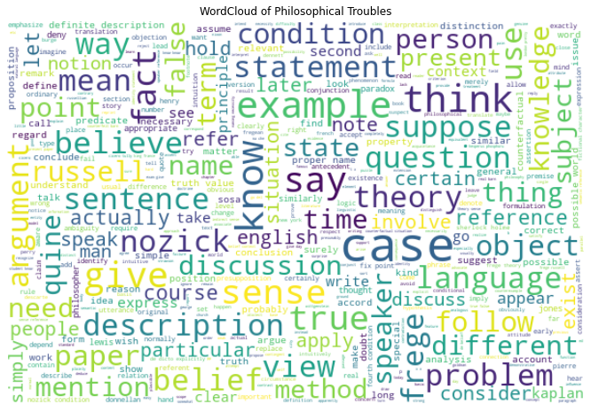

```python
showwordcloud(t1)
```

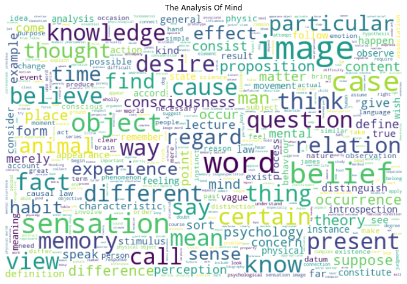

```python
t2 = texts[texts.title == 'The Analysis Of Mind'].text.iloc[0]
showwordcloud(t2, 'The Analysis Of Mind')
```

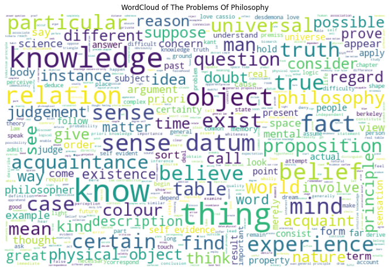

```python
t3 = texts[texts.title == 'The Problems Of Philosophy'].text.iloc[0]
showwordcloud(t3, 'WordCloud of The Problems Of Philosophy')
```

### Example2: Essential Works Of Lenin - Lenin & Marx communism

Lenin mentioned Marx 382 times in the work.  
Background: Lenin is the revelationary who opened the way to the nationalization of Marxism. Lenin not only studied the works of Marx but he studied what was written about Marx and Marxism by the opponents from the camp of the bourgeoisie and the petty-bourgeoisie. Together, they built Marxism–Leninism.

[figure not shown]

```python
Image("../figs/Marxism–Leninism.jpeg", width=400)
```

```python
temp_df1 = df[df.title == 'Essential Works Of Lenin']
temp_df1 = temp_df1[[x.find('Marx') != -1 for x in temp_df1.sentence_spacy]]
mentioned_sentence1 = list(temp_df1.sentence_spacy)
mentioned_sentence1[5:10]
```

```
["The main postulates in Marx's views on this question are as follows:",
 'Yet, due to a combination of circumstances and personality, he was unable to discuss these points in the abstract, but was drawn into the debate then widening the division between the two outlooks in Russian Marxism, a division that became final with the formal Bolshevik Menshevik split.',
 'Moreover, he took up and discussed at length, in polemic fashion, the internal issues then confronting Russian Marxism, thus producing a work considerably longer than he originally planned.',
 "What this 'new' tendency, which adopts a 'critical' attitude towards 'obsolete doctrinaire' Marxism, represents has been stated with sufficient precision by Bernstein, and demonstrated by Millerand.",
 'Thus, the demand for a definite change from revolutionary Social Democracy to bourgeois social reformism was accompanied by a no less definite turn towards bourgeois criticism of all the fundamental ideas of Marxism.']
```

### 1. sentiment analysis

**for the whole article:**

```python
df_output = pd.merge(df_t, t_df_cleaned, on='row_id', how='inner')
df_output
```

|  | row_id | sentence_lowered | sentiment_type | sentiment_score |
| --- | --- | --- | --- | --- |
| 0 | 1 | which are directly related to the question of ... | compound | 0.0000 |
| 1 | 2 | the fundamental process of the formation of a ... | compound | 0.0000 |
| 2 | 3 | this means that, one after another, various fo... | compound | 0.0000 |
| 3 | 4 | thus, agriculture itself becomes an industry (... | compound | 0.0000 |
| 4 | 5 | the direct deduction from the preceding postul... | compound | 0.0000 |
| ... | ... | ... | ... | ... |
| 4464 | 4465 | there is really no essential difference betwee... | compound | -0.5095 |
| 4465 | 4466 | taking this circumstance into consideration, w... | compound | 0.1689 |
| 4466 | 4467 | the experience of the commune has been not onl... | compound | -0.4968 |
| 4467 | 4468 | instead of inculcating in the workers' minds t... | compound | 0.1027 |
| 4468 | 4469 | the distortion and hushing up of the question ... | compound | -0.3724 |

4469 rows × 4 columns

```python
df_output.sentiment_score.describe()
```

```
count    4469.000000
mean        0.048487
std         0.424585
min        -0.978300
25%        -0.226300
50%         0.000000
75%         0.361200
max         0.969700
Name: sentiment_score, dtype: float64
```

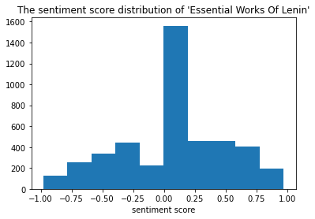

```python
fig,ax = plt.subplots(1,1);

plt.hist(df_output.sentiment_score);

ax.set_title("The sentiment score distribution of 'Essential Works Of Lenin'")
ax.set_xlabel('sentiment score');
```

The min value is -0.978300, which indicates the polarity or intensity of the most negative response is strongly negative (range of sentiment polarity score is -1 to +1).  
The max value is +0.969700, which indicates the polarity or intensity of the most positive response is highly positive.  
The mean value is +0.048487 which indicates the average polarity or intensity of sentiment across all responses is almost neutral.

**for sentences mentioning Marx:**

```python
df_marx = df_output[[x.find('marx') != -1 for x in df_output.sentence_lowered]]
df_marx
```

|  | row_id | sentence_lowered | sentiment_type | sentiment_score |
| --- | --- | --- | --- | --- |
| 12 | 13 | the realization of the product in capitalist s... | compound | 0.8807 |
| 13 | 14 | having laid down these main theoretical postul... | compound | -0.4865 |
| 14 | 15 | marx's theory of realization also shed light o... | compound | 0.0000 |
| 16 | 17 | that is precisely why the marxian theory nowhe... | compound | 0.0000 |
| 53 | 54 | as the starting point of this genesis marx tak... | compound | -0.2960 |
| ... | ... | ... | ... | ... |
| 4424 | 4425 | his question about officials clearly shows tha... | compound | 0.4019 |
| 4433 | 4434 | it was precisely the example of the commune th... | compound | 0.0000 |
| 4434 | 4435 | in essence, the whole of kautsky's argument ag... | compound | 0.6461 |
| 4441 | 4442 | marx's critico analytical genius perceived in ... | compound | -0.3703 |
| 4445 | 4446 | marx teaches us to avoid both kinds of error; ... | compound | -0.7269 |

339 rows × 4 columns

```python
df_marx.sentiment_score.describe()
```

```
count    339.000000
mean      -0.001307
std        0.424868
min       -0.938200
25%       -0.298350
50%        0.000000
75%        0.308000
max        0.959600
Name: sentiment_score, dtype: float64
```

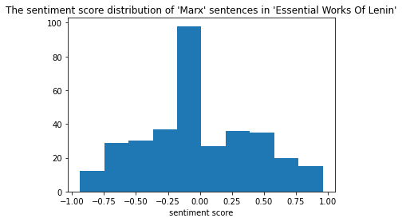

```python
fig,ax = plt.subplots(1,1);

plt.hist(df_marx.sentiment_score);

ax.set_title("The sentiment score distribution of 'Marx' sentences in 'Essential Works Of Lenin'")
ax.set_xlabel('sentiment score');
```

**example of highly negative:**

```python
df_marx[df_marx.sentiment_score < -0.8].sentence_lowered.iloc[0]
```

```
"marx wrote: 'the working class in the course of its development will substitute for the old civil society an association which will exclude classes and their antagonism, and there will be no more political power properly so called, since political power is precisely the official expression of antag…
```

**example of highly positive:**

```python
df_marx[df_marx.sentiment_score < 0.9].sentence_lowered.iloc[0]
```

```
'the realization of the product in capitalist society (and, consequently, the realization of surplus value) cannot be explained unless we understand that: the value of the social product, like that of the individual product, is divided into three parts and not into two (constant capital variable cap…
```

The result makes sense as most citations are just proof of arguements, not a personal attitude towards Marx.

### 2. similarity

```python
df[df.author == 'Marx'].title.drop_duplicates()
```

```
289938                    Capital
302934    The Communist Manifesto
Name: title, dtype: object
```

The average similarity of Lenin's work with others is 0.3273.

But the similarity of Lenin's work with 'Capital' and 'The Communist Manifesto' are 0.4089 and 0.5230. 'The Communist Manifesto' is the article with the largest similarity. Also 'Capital' has the similarity higher than average.

## Correlation btw similarity and citation

Generally, is there a statistical correlation btw similarity and citation. As intuitively, we believe that the more a philosopher is quoted or referred to, the more similar their ideas and articles would be.

```python
for column in similarity.columns:
     similarity.loc[title2author[column]][column] = np.nan
similarity
```

|  | Plato - Complete Works | Aristotle - Complete Works | Second Treatise On Government | Essay Concerning Human Understanding | A Treatise Of Human Nature | Dialogues Concerning Natural Religion | Three Dialogues | A Treatise Concerning The Principles Of Human Knowledge | Ethics | On The Improvement Of Understanding | ... | Enchiridion | Meditations | The Antichrist | Beyond Good And Evil | Ecce Homo | Twilight Of The Idols | Thus Spake Zarathustra | Vindication Of The Rights Of Woman | The Second Sex | Women, Race, And Class |
| --- | --- | --- | --- | --- | --- | --- | --- | --- | --- | --- | --- | --- | --- | --- | --- | --- | --- | --- | --- | --- | --- |
| Plato | NaN | 0.742036 | 0.553567 | 0.536947 | 0.504460 | 0.552436 | 0.501190 | 0.508259 | 0.510620 | 0.516559 | ... | 0.595235 | 0.414771 | 0.569533 | 0.646533 | 0.619137 | 0.669326 | 0.381272 | 0.533567 | 0.531952 | 0.249626 |
| Aristotle | 0.742036 | NaN | 0.504813 | 0.570988 | 0.601960 | 0.618014 | 0.553917 | 0.594576 | 0.569026 | 0.584235 | ... | 0.560729 | 0.415864 | 0.525343 | 0.626470 | 0.595013 | 0.646227 | 0.328278 | 0.542201 | 0.516848 | 0.231757 |
| Locke | 0.545257 | 0.537901 | NaN | NaN | 0.591123 | 0.552876 | 0.511238 | 0.614453 | 0.509601 | 0.533997 | ... | 0.449348 | 0.354939 | 0.448010 | 0.515680 | 0.450149 | 0.520336 | 0.276076 | 0.488112 | 0.401120 | 0.177360 |
| Hume | 0.528448 | 0.609987 | 0.509977 | 0.634022 | NaN | NaN | 0.572282 | 0.655000 | 0.544059 | 0.567533 | ... | 0.460917 | 0.361345 | 0.468860 | 0.550450 | 0.504250 | 0.573379 | 0.252290 | 0.555943 | 0.412669 | 0.160655 |
| Berkeley | 0.504724 | 0.574246 | 0.358345 | 0.767346 | 0.652829 | 0.574454 | NaN | NaN | 0.609218 | 0.694728 | ... | 0.441534 | 0.359549 | 0.397977 | 0.443302 | 0.426565 | 0.470962 | 0.228955 | 0.420715 | 0.310066 | 0.122320 |
| Spinoza | 0.513589 | 0.576630 | 0.367904 | 0.675694 | 0.586712 | 0.524879 | 0.616540 | 0.687406 | NaN | NaN | ... | 0.467406 | 0.352192 | 0.420016 | 0.461285 | 0.423370 | 0.494333 | 0.220672 | 0.433965 | 0.336836 | 0.114862 |
| Leibniz | 0.651212 | 0.637403 | 0.515623 | 0.514476 | 0.561313 | 0.628360 | 0.477703 | 0.518991 | 0.573363 | 0.510473 | ... | 0.510893 | 0.383026 | 0.623933 | 0.621424 | 0.568991 | 0.680697 | 0.334174 | 0.519811 | 0.464535 | 0.191757 |
| Descartes | 0.603302 | 0.647299 | 0.423614 | 0.635451 | 0.623776 | 0.609160 | 0.633142 | 0.661509 | 0.578867 | 0.657513 | ... | 0.485993 | 0.371375 | 0.508946 | 0.530697 | 0.537434 | 0.580963 | 0.274511 | 0.487482 | 0.409129 | 0.188387 |
| Malebranche | 0.657199 | 0.710487 | 0.471806 | 0.668016 | 0.671425 | 0.615404 | 0.622199 | 0.689689 | 0.662336 | 0.648599 | ... | 0.500465 | 0.386776 | 0.549435 | 0.608187 | 0.546213 | 0.631884 | 0.323600 | 0.569507 | 0.484772 | 0.184851 |
| Russell | 0.544398 | 0.606835 | 0.350181 | 0.535050 | 0.585997 | 0.534244 | 0.533418 | 0.557779 | 0.457455 | 0.561311 | ... | 0.417610 | 0.298995 | 0.432400 | 0.499859 | 0.489365 | 0.533534 | 0.229012 | 0.409487 | 0.376981 | 0.156281 |
| Moore | 0.602851 | 0.641740 | 0.370630 | 0.598539 | 0.620863 | 0.540792 | 0.629052 | 0.619915 | 0.471597 | 0.606555 | ... | 0.451061 | 0.325953 | 0.445859 | 0.508505 | 0.515946 | 0.563940 | 0.226857 | 0.414500 | 0.380211 | 0.145080 |
| Wittgenstein | 0.532667 | 0.500081 | 0.289804 | 0.399777 | 0.396960 | 0.390372 | 0.395625 | 0.399599 | 0.311786 | 0.407204 | ... | 0.350515 | 0.230765 | 0.381893 | 0.427767 | 0.441493 | 0.468547 | 0.214480 | 0.309852 | 0.332297 | 0.136209 |
| Lewis | 0.503497 | 0.520013 | 0.364263 | 0.405279 | 0.455720 | 0.476377 | 0.376315 | 0.398553 | 0.332001 | 0.398146 | ... | 0.367027 | 0.249585 | 0.390718 | 0.449498 | 0.404624 | 0.464042 | 0.194166 | 0.345791 | 0.347173 | 0.150773 |
| Quine | 0.387214 | 0.425155 | 0.269534 | 0.347946 | 0.359911 | 0.366232 | 0.309612 | 0.349141 | 0.268706 | 0.343652 | ... | 0.277307 | 0.196602 | 0.331932 | 0.372756 | 0.365893 | 0.392638 | 0.175104 | 0.298795 | 0.293843 | 0.145089 |
| Popper | 0.367733 | 0.415725 | 0.256914 | 0.317416 | 0.382747 | 0.377755 | 0.276615 | 0.317131 | 0.253751 | 0.329255 | ... | 0.268316 | 0.189305 | 0.312905 | 0.352060 | 0.353367 | 0.384633 | 0.162017 | 0.273010 | 0.276630 | 0.125959 |
| Kripke | 0.525500 | 0.513265 | 0.328858 | 0.400242 | 0.425158 | 0.429401 | 0.393946 | 0.403173 | 0.323576 | 0.393846 | ... | 0.340220 | 0.243626 | 0.387556 | 0.439361 | 0.439248 | 0.472042 | 0.209816 | 0.333726 | 0.355936 | 0.161788 |
| Foucault | 0.425591 | 0.455486 | 0.339385 | 0.357081 | 0.387431 | 0.416116 | 0.312761 | 0.352303 | 0.310418 | 0.359444 | ... | 0.292677 | 0.230857 | 0.418624 | 0.438280 | 0.466313 | 0.482080 | 0.212437 | 0.359000 | 0.388008 | 0.229599 |
| Derrida | 0.502038 | 0.539930 | 0.350890 | 0.426501 | 0.484529 | 0.489553 | 0.396494 | 0.438359 | 0.374429 | 0.425478 | ... | 0.376052 | 0.279181 | 0.473174 | 0.520421 | 0.530108 | 0.572521 | 0.259746 | 0.394183 | 0.431120 | 0.174654 |
| Deleuze | 0.399354 | 0.480593 | 0.300972 | 0.375622 | 0.446894 | 0.402788 | 0.334385 | 0.374991 | 0.338611 | 0.379893 | ... | 0.304045 | 0.212071 | 0.360659 | 0.415909 | 0.392521 | 0.444969 | 0.195054 | 0.336803 | 0.374390 | 0.165141 |
| Merleau-Ponty | 0.521664 | 0.612272 | 0.387734 | 0.494663 | 0.569817 | 0.525172 | 0.508875 | 0.539319 | 0.471322 | 0.531256 | ... | 0.408958 | 0.294777 | 0.467970 | 0.522766 | 0.501897 | 0.561557 | 0.243122 | 0.426268 | 0.456898 | 0.177297 |
| Husserl | 0.422347 | 0.480784 | 0.291249 | 0.394678 | 0.459171 | 0.456662 | 0.391860 | 0.419195 | 0.351306 | 0.466765 | ... | 0.313143 | 0.251400 | 0.397886 | 0.437930 | 0.431864 | 0.476588 | 0.196211 | 0.344280 | 0.343370 | 0.131070 |
| Heidegger | 0.435025 | 0.473531 | 0.280573 | 0.355553 | 0.384274 | 0.380922 | 0.335661 | 0.357989 | 0.327736 | 0.403523 | ... | 0.336837 | 0.253047 | 0.396705 | 0.436046 | 0.431666 | 0.470782 | 0.210217 | 0.324613 | 0.336377 | 0.129303 |
| Kant | 0.425977 | 0.506102 | 0.364686 | 0.411876 | 0.540100 | 0.520767 | 0.408017 | 0.441365 | 0.407374 | 0.462710 | ... | 0.369567 | 0.278086 | 0.409674 | 0.442413 | 0.420176 | 0.490530 | 0.194318 | 0.397940 | 0.327829 | 0.121354 |
| Fichte | 0.573419 | 0.612004 | 0.462357 | 0.441368 | 0.593992 | 0.568275 | 0.431732 | 0.448334 | 0.438265 | 0.474273 | ... | 0.451406 | 0.342970 | 0.497645 | 0.549081 | 0.563309 | 0.624844 | 0.271906 | 0.471795 | 0.445515 | 0.170590 |
| Hegel | 0.463731 | 0.553554 | 0.373798 | 0.419590 | 0.505990 | 0.474613 | 0.398502 | 0.442087 | 0.403968 | 0.458650 | ... | 0.370776 | 0.274515 | 0.439318 | 0.484507 | 0.482195 | 0.536882 | 0.226144 | 0.387211 | 0.394118 | 0.155258 |
| Marx | 0.257744 | 0.290567 | 0.283755 | 0.209287 | 0.246406 | 0.249271 | 0.175027 | 0.213246 | 0.187841 | 0.206198 | ... | 0.203220 | 0.134621 | 0.260643 | 0.301154 | 0.280993 | 0.310868 | 0.130319 | 0.249686 | 0.261090 | 0.187547 |
| Lenin | 0.357688 | 0.384351 | 0.308187 | 0.264253 | 0.317243 | 0.324583 | 0.226318 | 0.260438 | 0.220340 | 0.262005 | ... | 0.248845 | 0.178610 | 0.333696 | 0.379234 | 0.381648 | 0.410308 | 0.171645 | 0.294043 | 0.329032 | 0.266734 |
| Smith | 0.405192 | 0.413589 | 0.432827 | 0.330740 | 0.402953 | 0.420525 | 0.257613 | 0.310096 | 0.257259 | 0.264175 | ... | 0.326780 | 0.227163 | 0.347675 | 0.411373 | 0.395023 | 0.409900 | 0.202096 | 0.370746 | 0.323291 | 0.200353 |
| Ricardo | 0.223043 | 0.247403 | 0.246158 | 0.184782 | 0.235698 | 0.232058 | 0.150898 | 0.183197 | 0.161878 | 0.168459 | ... | 0.197569 | 0.123461 | 0.194599 | 0.218352 | 0.206474 | 0.229454 | 0.107344 | 0.211812 | 0.180539 | 0.108416 |
| Keynes | 0.291045 | 0.332449 | 0.247418 | 0.241582 | 0.291932 | 0.288662 | 0.210170 | 0.238524 | 0.209872 | 0.231847 | ... | 0.220945 | 0.149848 | 0.246020 | 0.290061 | 0.283364 | 0.305480 | 0.134826 | 0.252606 | 0.242664 | 0.142796 |
| Epictetus | 0.595235 | 0.560729 | 0.459604 | 0.439092 | 0.453222 | 0.468613 | 0.441561 | 0.441507 | 0.484844 | 0.449967 | ... | NaN | 0.387040 | 0.421581 | 0.474739 | 0.442198 | 0.498782 | 0.274195 | 0.430475 | 0.368872 | 0.148157 |
| Marcus Aurelius | 0.414771 | 0.415864 | 0.360754 | 0.349124 | 0.345703 | 0.376987 | 0.368270 | 0.350829 | 0.361401 | 0.342982 | ... | 0.387040 | NaN | 0.333091 | 0.355822 | 0.386763 | 0.424328 | 0.645061 | 0.336625 | 0.269128 | 0.101634 |
| Nietzsche | 0.577160 | 0.544266 | 0.458227 | 0.425874 | 0.439567 | 0.500124 | 0.376588 | 0.410517 | 0.409865 | 0.398006 | ... | 0.422299 | 0.429013 | NaN | NaN | NaN | NaN | NaN | 0.498783 | 0.496901 | 0.224392 |
| Wollstonecraft | 0.533567 | 0.542201 | 0.505128 | 0.471096 | 0.539896 | 0.571990 | 0.387757 | 0.453674 | 0.460655 | 0.407274 | ... | 0.430475 | 0.336625 | 0.485795 | 0.614928 | 0.506331 | 0.573058 | 0.313804 | NaN | 0.679300 | 0.458224 |
| Beauvoir | 0.531952 | 0.516848 | 0.430937 | 0.371304 | 0.397897 | 0.427440 | 0.285881 | 0.334252 | 0.361132 | 0.312540 | ... | 0.368872 | 0.269128 | 0.481962 | 0.592189 | 0.525123 | 0.569988 | 0.315243 | 0.679300 | NaN | 0.497830 |
| Davis | 0.249626 | 0.231757 | 0.206558 | 0.148162 | 0.151299 | 0.170012 | 0.113937 | 0.130703 | 0.113024 | 0.116700 | ... | 0.148157 | 0.101634 | 0.229343 | 0.248270 | 0.260589 | 0.252579 | 0.131178 | 0.458224 | 0.497830 | NaN |

36 rows × 59 columns

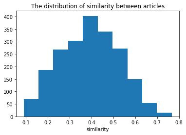

```python
fig,ax = plt.subplots(1,1);

plt.hist(similar);

ax.set_title("The distribution of similarity between articles")
ax.set_xlabel('similarity');
```

```python
# references = references.set_index('philosophers')
references
```

| philosophers | Plato - Complete Works | Aristotle - Complete Works | Second Treatise On Government | Essay Concerning Human Understanding | A Treatise Of Human Nature | Dialogues Concerning Natural Religion | Three Dialogues | A Treatise Concerning The Principles Of Human Knowledge | Ethics | On The Improvement Of Understanding | ... | Enchiridion | Meditations | The Antichrist | Beyond Good And Evil | Ecce Homo | Twilight Of The Idols | Thus Spake Zarathustra | Vindication Of The Rights Of Woman | The Second Sex | Women, Race, And Class |
| --- | --- | --- | --- | --- | --- | --- | --- | --- | --- | --- | --- | --- | --- | --- | --- | --- | --- | --- | --- | --- | --- |
| Plato | 31 | 76 | 0 | 7 | 2 | 1 | 0 | 0 | 0 | 0 | ... | 0 | 7 | 2 | 23 | 4 | 26 | 0 | 2 | 29 | 0 |
| Aristotle | 0 | 0 | 0 | 2 | 0 | 0 | 0 | 2 | 0 | 0 | ... | 0 | 0 | 1 | 0 | 2 | 4 | 0 | 0 | 10 | 0 |
| Locke | 8 | 8 | 0 | 2 | 3 | 0 | 0 | 1 | 0 | 0 | ... | 0 | 0 | 0 | 4 | 0 | 0 | 3 | 2 | 19 | 3 |
| Hume | 0 | 0 | 0 | 0 | 0 | 0 | 0 | 0 | 0 | 0 | ... | 0 | 0 | 0 | 1 | 0 | 0 | 0 | 1 | 0 | 0 |
| Berkeley | 0 | 0 | 0 | 0 | 1 | 0 | 0 | 0 | 0 | 0 | ... | 0 | 0 | 0 | 1 | 0 | 0 | 0 | 0 | 0 | 0 |
| Spinoza | 0 | 0 | 0 | 0 | 6 | 0 | 1 | 0 | 1 | 0 | ... | 0 | 0 | 1 | 5 | 0 | 4 | 0 | 0 | 1 | 0 |
| Leibniz | 0 | 0 | 0 | 0 | 0 | 1 | 0 | 0 | 0 | 0 | ... | 0 | 0 | 0 | 1 | 1 | 2 | 0 | 0 | 1 | 0 |
| Descartes | 0 | 0 | 0 | 4 | 0 | 0 | 0 | 0 | 2 | 0 | ... | 0 | 0 | 2 | 3 | 1 | 2 | 0 | 0 | 1 | 0 |
| Malebranche | 0 | 0 | 0 | 0 | 1 | 0 | 1 | 0 | 0 | 0 | ... | 0 | 0 | 0 | 0 | 0 | 0 | 0 | 0 | 0 | 0 |
| Russell | 0 | 0 | 0 | 0 | 0 | 0 | 0 | 0 | 0 | 0 | ... | 0 | 0 | 0 | 0 | 0 | 0 | 0 | 0 | 0 | 4 |
| Moore | 0 | 1 | 0 | 0 | 0 | 0 | 0 | 0 | 0 | 0 | ... | 0 | 0 | 0 | 0 | 0 | 0 | 0 | 0 | 0 | 0 |
| Wittgenstein | 0 | 0 | 0 | 0 | 0 | 0 | 0 | 0 | 0 | 0 | ... | 0 | 0 | 0 | 0 | 0 | 0 | 0 | 0 | 0 | 0 |
| Lewis | 0 | 0 | 0 | 0 | 0 | 0 | 0 | 0 | 0 | 0 | ... | 0 | 0 | 0 | 0 | 0 | 0 | 0 | 1 | 2 | 1 |
| Quine | 0 | 0 | 0 | 0 | 0 | 0 | 0 | 0 | 1 | 0 | ... | 0 | 0 | 0 | 0 | 0 | 0 | 0 | 0 | 0 | 0 |
| Popper | 0 | 0 | 0 | 0 | 0 | 0 | 0 | 0 | 0 | 0 | ... | 0 | 0 | 0 | 0 | 0 | 0 | 0 | 0 | 0 | 0 |
| Kripke | 0 | 0 | 0 | 0 | 0 | 0 | 0 | 0 | 0 | 0 | ... | 0 | 0 | 0 | 0 | 0 | 0 | 0 | 0 | 0 | 0 |
| Foucault | 0 | 0 | 0 | 0 | 1 | 0 | 0 | 0 | 0 | 0 | ... | 0 | 0 | 0 | 0 | 0 | 0 | 0 | 0 | 0 | 0 |
| Derrida | 0 | 0 | 0 | 0 | 0 | 0 | 0 | 0 | 0 | 0 | ... | 0 | 0 | 0 | 0 | 0 | 0 | 0 | 0 | 0 | 0 |
| Deleuze | 0 | 0 | 0 | 0 | 0 | 0 | 0 | 0 | 0 | 0 | ... | 0 | 0 | 0 | 0 | 0 | 0 | 0 | 0 | 0 | 0 |
| Merleau-Ponty | 0 | 0 | 0 | 0 | 0 | 0 | 0 | 0 | 0 | 0 | ... | 0 | 0 | 0 | 0 | 0 | 0 | 0 | 0 | 0 | 0 |
| Husserl | 0 | 0 | 0 | 0 | 0 | 0 | 0 | 0 | 0 | 0 | ... | 0 | 0 | 0 | 0 | 0 | 0 | 0 | 0 | 0 | 0 |
| Heidegger | 0 | 0 | 0 | 0 | 0 | 0 | 0 | 0 | 0 | 0 | ... | 0 | 0 | 0 | 0 | 0 | 0 | 0 | 0 | 5 | 0 |
| Kant | 0 | 0 | 0 | 0 | 0 | 0 | 0 | 0 | 0 | 0 | ... | 0 | 0 | 11 | 11 | 2 | 22 | 0 | 0 | 2 | 0 |
| Fichte | 0 | 0 | 0 | 0 | 0 | 0 | 0 | 0 | 0 | 0 | ... | 0 | 0 | 0 | 2 | 1 | 0 | 0 | 0 | 0 | 0 |
| Hegel | 0 | 0 | 0 | 0 | 0 | 0 | 0 | 0 | 0 | 0 | ... | 0 | 0 | 0 | 5 | 5 | 2 | 0 | 0 | 18 | 1 |
| Marx | 0 | 0 | 0 | 0 | 0 | 0 | 0 | 0 | 0 | 0 | ... | 0 | 0 | 0 | 0 | 0 | 0 | 0 | 0 | 12 | 9 |
| Lenin | 0 | 0 | 0 | 0 | 0 | 0 | 0 | 0 | 0 | 0 | ... | 0 | 0 | 0 | 0 | 0 | 0 | 0 | 0 | 3 | 1 |
| Smith | 12 | 11 | 0 | 3 | 0 | 0 | 0 | 0 | 0 | 0 | ... | 1 | 0 | 0 | 0 | 0 | 0 | 1 | 2 | 7 | 4 |
| Ricardo | 0 | 0 | 0 | 0 | 0 | 0 | 0 | 0 | 0 | 0 | ... | 0 | 0 | 0 | 0 | 0 | 0 | 0 | 0 | 0 | 0 |
| Keynes | 0 | 0 | 0 | 0 | 0 | 0 | 0 | 0 | 0 | 0 | ... | 0 | 0 | 0 | 0 | 0 | 0 | 0 | 0 | 0 | 0 |
| Epictetus | 0 | 0 | 0 | 0 | 0 | 0 | 0 | 0 | 0 | 0 | ... | 0 | 5 | 0 | 0 | 0 | 0 | 0 | 0 | 0 | 0 |
| Marcus Aurelius | 0 | 0 | 0 | 0 | 0 | 0 | 0 | 0 | 0 | 0 | ... | 0 | 0 | 0 | 0 | 0 | 0 | 0 | 0 | 0 | 0 |
| Nietzsche | 0 | 0 | 0 | 0 | 0 | 0 | 0 | 0 | 0 | 0 | ... | 0 | 0 | 3 | 0 | 0 | 1 | 0 | 0 | 13 | 0 |
| Wollstonecraft | 0 | 0 | 0 | 0 | 0 | 0 | 0 | 0 | 0 | 0 | ... | 0 | 0 | 0 | 0 | 0 | 0 | 0 | 0 | 2 | 1 |
| Beauvoir | 0 | 0 | 0 | 0 | 0 | 0 | 0 | 0 | 0 | 0 | ... | 0 | 0 | 0 | 0 | 0 | 0 | 0 | 0 | 5 | 0 |
| Davis | 0 | 0 | 0 | 0 | 0 | 0 | 0 | 0 | 0 | 0 | ... | 0 | 0 | 0 | 0 | 0 | 0 | 0 | 0 | 1 | 0 |

36 rows × 59 columns

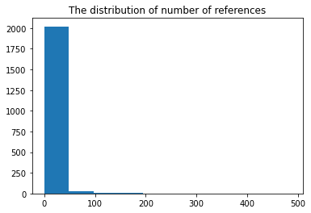

```python
fig,ax = plt.subplots(1,1);

plt.hist(refer);

ax.set_title("The distribution of number of references");
```

The distribution of number of reference is highly right skewed. So i applied the log() function and:

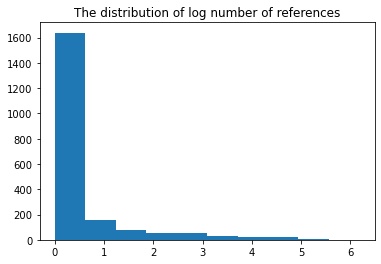

```python
refer_log = [log1p(x) for x in refer]

fig,ax = plt.subplots(1,1);

plt.hist(refer_log);

ax.set_title("The distribution of log number of references");
```

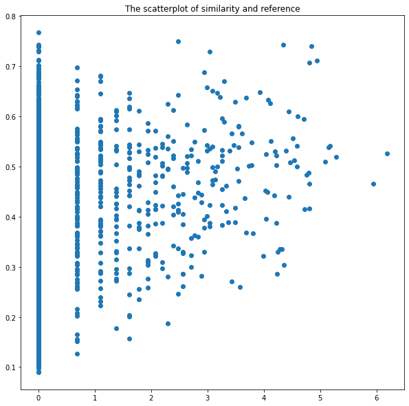

```python
fig,ax = plt.subplots(1, 1, figsize=(10, 10));

pyplot.scatter(refer_log, similar)

ax.set_title("The scatterplot of similarity and reference");
```

```python
# calculate the Pearson's correlation between two variables
from numpy.random import randn
from numpy.random import seed
from scipy.stats import pearsonr

# seed random number generator
seed(1)
# prepare data

# calculate Pearson's correlation
corr, _ = pearsonr(refer_log, similar)
print('Pearsons correlation: %.3f' % corr)
```

```
Pearsons correlation: 0.233
```

Statistically, the result approves a small correlation between similarity and reference. yeah!!